# Part II - Ford GoBike Trip Dataset Investifation

## by Zaid Baig A

## Investigation Overview

> Data consists of info about trips taken by service's members, their types, their age, their gender, stations of starting and ending trips, duration of trips etc. The goal of this project will be to investigate and find new features and new insights in relation to the Ford GoBike dataset. To find the nature of the users, how often are these being used, when are they being used the maximum, etc.

## Dataset Overview

> The Dataset consists of a total of 183,412 records and 16 attributes

> The main features in the dataset according to the initial analysis are: duration_sec, start_station_id, end_station_id, bike_id, user_type, member_birth_year, member_gender, bike_share_for_all_trip

> The features that will help support the investigation are: duration_sec, start_station_id, end_station_id, user_type, member_birth_year, member_gender

## Univariant Visualization Analysis

> Majority of the users have birth years between between 1980s and 2000s, i.e, their approx age range is 20 to 40

> In our gender comaprison we find that the majority of the users are actually male with more than 70%. With women only having a little over 20% of the distribution

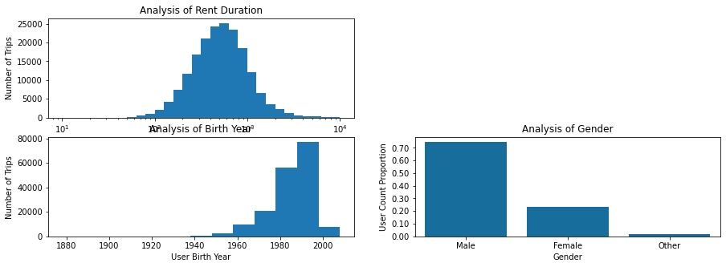

## Bivariant Visualization Analysis

> The number of users in weekends are way lesser than the number of users during the weekdays

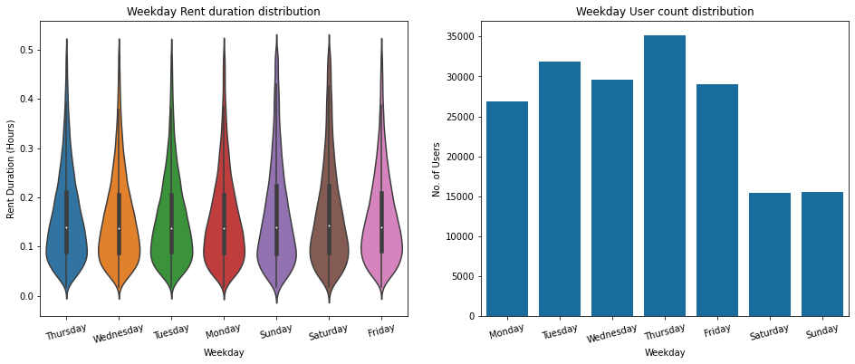

> The most popular station where users have as the starting point for the bike rental is "Market Street at 10th street" and the favourite end station to conclude their usage is "San Francisco Caltrain Station 2"

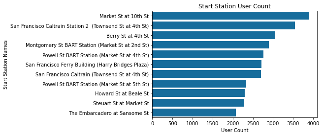

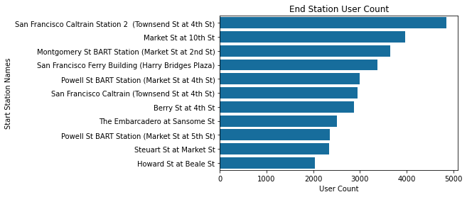

## Multivariant Visualization Analysis

> Most non-subcriber type customer make use of rental bikes on more than the subcribers in terms of rent duration

> Subscribers rent duration is constantly at 10 mins during Monday to Friday and about 12 mins during the weekends. This looks like subscribers have a fixed schedule and have incorporated the use rental bikes in their day to day activities.

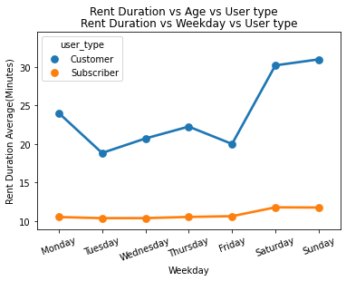

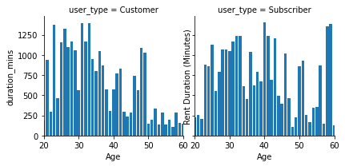